# Exploring Factors that Influence Used BMW Prices

### Main Research Question:

What factors are most strongly associated with the price of used BMW vehicles?

## Problem Definition

The goal of this project is to explore what factors are most strongly associated with the price of used BMW vehicles. Used car pricing is influenced by many characteristics including age, mileage, engine size, transmission type, and fuel type. Understanding how these factors relate to price can provide insight into depreciation patterns.

This question is relevant to car buyers, sellers, dealerships, and automotive analysts. Buyers may want to understand what features justify higher prices, while sellers may want to understand how their vehicle compares to others on the market.

Rather than attempting to predict price, this project focuses on identifying patterns and relationships using exploratory data analysis.

## Data Description

The dataset used in this project comes from Kaggle (BMW Cars Dataset) and contains listings of used BMW vehicles. Each row represents one vehicle listing. The dataset contains 10,781 rows and 9 columns.

The columns include:

- model: BMW model name
- year: Year the vehicle was manufactured
- price: Listing price
- transmission: Transmission type
- mileage: Total miles driven
- fuelType: Fuel type (petrol, diesel, hybrid)
- tax: Road tax amount
- mpg: Miles per gallon
- engineSize: Engine size in liters

The dataset does not include information about vehicle condition, accident history, or geographic location. These missing factors may influence price but are not captured in this dataset. Therefore, conclusions from this dataset are limited to the variables provided.

## Data Cleaning & Preparation

```python
# Import Pandas
# Enable data manipulation and analysis through DataFrames
import pandas as pd

# Load dataset
# Convert CSV file into a DataFrame for analysis
df = pd.read_csv("bmw.csv")
```

```python
# Preview dataset
# Display first 5 rows to understand structure and content
print(df.head())
```

```
       model  year  price transmission  mileage fuelType  tax   mpg  \
0   5 Series  2014  11200    Automatic    67068   Diesel  125  57.6
1   6 Series  2018  27000    Automatic    14827   Petrol  145  42.8
2   5 Series  2016  16000    Automatic    62794   Diesel  160  51.4
3   1 Series  2017  12750    Automatic    26676   Diesel  145  72.4
4   7 Series  2014  14500    Automatic    39554   Diesel  160  50.4

   engineSize
0         2.0
1         2.0
2         3.0
3         1.5
4         3.0
```

```python
# Verify dataset size, columns, and data types
print(df.shape)
print(df.columns)
print(df.info())
```

```
(10781, 9)
Index(['model', 'year', 'price', 'transmission', 'mileage', 'fuelType', 'tax',
       'mpg', 'engineSize'],
      dtype='str')
<class 'pandas.DataFrame'>
RangeIndex: 10781 entries, 0 to 10780
Data columns (total 9 columns):
 #   Column        Non-Null Count  Dtype
---  ------        --------------  -----
 0   model         10781 non-null  str
 1   year          10781 non-null  int64
 2   price         10781 non-null  int64
 3   transmission  10781 non-null  str
 4   mileage       10781 non-null  int64
 5   fuelType      10781 non-null  str
 6   tax           10781 non-null  int64
 7   mpg           10781 non-null  float64
 8   engineSize    10781 non-null  float64
dtypes: float64(2), int64(4), str(3)
memory usage: 758.2 KB
None
```

```python
# Remove duplicates
# Decrease risk of bias through over-representation of certain data points (i.e vehicles)
df = df.drop_duplicates()
```

```python
# Remove impossible values
# (i.e negative values for price and mileage)
df = df[df["price"] >= 0]
df = df[df["mileage"] >= 0]
```

```python
# Convert categorical columns to category data type
df["model"] = df["model"].astype("category")
df["transmission"] = df["transmission"].astype("category")
df["fuelType"] = df["fuelType"].astype("category")
```

```python
# Create new column for car age
df["car_age"] = 2024 - df["year"]
```

### Data cleaning steps performed:

- Removed duplicate entries to avoid overrepresentation of vehicle listings
- Ensured that price and mileage values were valid by removing any impossible or unrealistic entries
- Converted categorical variables to appropriate types to improve clarity
- Created a new variable named "car_age" to better analyze depreciation effects

## Data Understanding & Visualization

```python
# Import visualization libraries
import matplotlib.pyplot as plt
import seaborn as sns
```

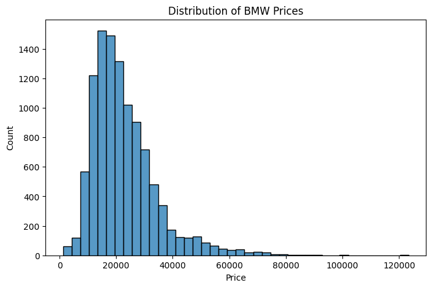

```python
# Identify price distribution

# Figure size (8 inches wide, 5 inches tall)
plt.figure(figsize=(8, 5))
# More bins/bars (40) for better resolution of price distribution
sns.histplot(df["price"], bins=40)
# Title and axis labels for clarity
plt.title("Distribution of BMW Prices")
plt.xlabel("Price")
plt.ylabel("Count")
# Display the plot
plt.show()
```

### Price Distribution

Visualization Type:

- Histogram

Reason for visualization choice:

- Show how price values are distributed across the dataset
- Help identify skewness, spread, and potential outliers

Findings:

- The distribution is right-skewed
- Indicates most vehicles fall in lower-to-mid price ranges
- Fewer high-priced models

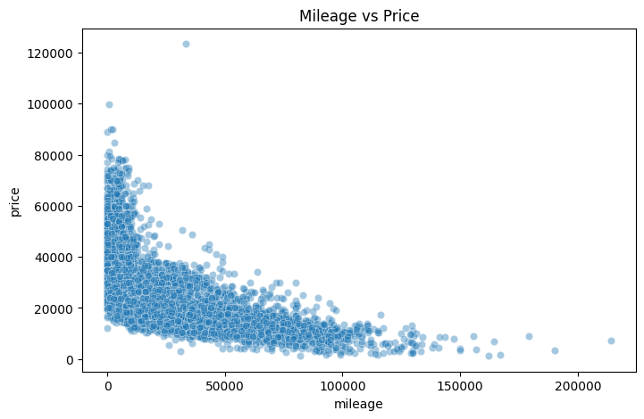

```python
# Mileage vs Price
# Examine depreciation of car value with mileage

# Figure size (8 inches wide, 5 inches tall)
plt.figure(figsize=(8, 5))
# Scatter plot with mileage on x-axis and price on y-axis
# alpha=0.4 for better visibility of overlapping points
sns.scatterplot(x="mileage", y="price", data=df, alpha=0.4)
# Title
plt.title("Mileage vs Price")
# Display the plot
plt.show()
```

### Mileage vs Price

Visualization Type:

- Scatterplot

Reason for visualization choice:

- Examine depreciation relationship

Findings:

- Strong negative relationship between mileage and price

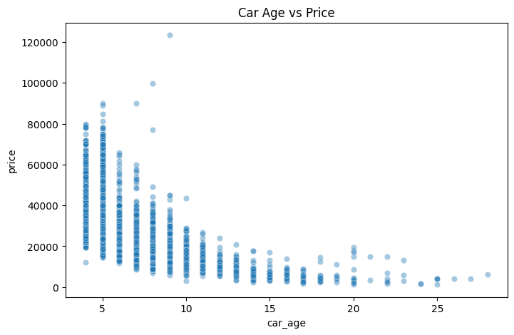

```python
# Car Age vs Price
# Examine depreciation of car value with age

# Figure size (8 inches wide, 5 inches tall)
plt.figure(figsize=(8, 5))
# Scatter plot with car age on x-axis and price on y-axis
# alpha=0.4 for better visibility of overlapping points
sns.scatterplot(x="car_age", y="price", data=df, alpha=0.4)
# Title
plt.title("Car Age vs Price")
# Display the plot
plt.show()
```

### Car Age vs Price

Visualization Type:

- Scatterplot

Reason for visualization choice:

- Examine depreciation relationship

Findings:

- Strong negative relationship between car_age and price

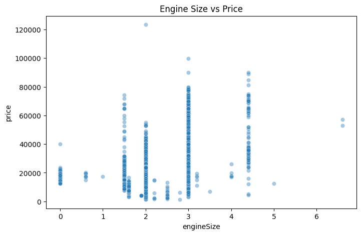

```python
# Engine Size vs Price
# Examine depreciation of car value with engine size

# Figure size (8 inches wide, 5 inches tall)
plt.figure(figsize=(8, 5))
# Scatter plot with engine size on x-axis and price on y-axis
# alpha=0.4 for better visibility of overlapping points
sns.scatterplot(x="engineSize", y="price", data=df, alpha=0.4)
# Title
plt.title("Engine Size vs Price")
# Display the plot
plt.show()
```

### Engine Size vs Price

Visualization Type:

- Scatterplot

Reason for visualization choice:

- Examine trends between engineSize and price

Findings:

- Moderate positive relationship between engineSize and price

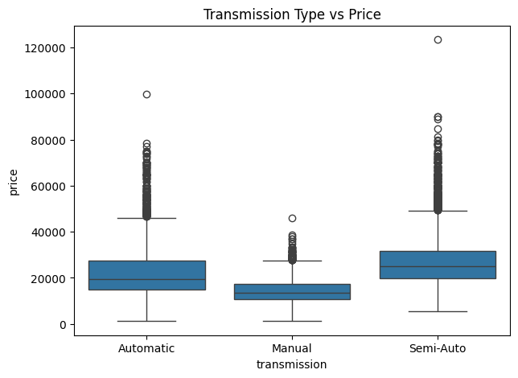

```python
# Transmission Type vs Price
# Examine depreciation of car value with transmission type
# Box plot shows median, quartiles, and outliers for price by transmission type

# Figure size (7 inches wide, 5 inches tall)
plt.figure(figsize=(7, 5))
# Box plot with transmission type on x-axis and price on y-axis
sns.boxplot(x="transmission", y="price", data=df)
# Title
plt.title("Transmission Type vs Price")
# Display the plot
plt.show()
```

### Transmission Type vs Price

Visualization Type:

- Boxplot

Reason for visualization choice:

- Compare median prices and distribution spread
- Categorical

Findings:

- There are differences in median prices across transmission types
- Some transmission types tend to have slightly lower or higher prices

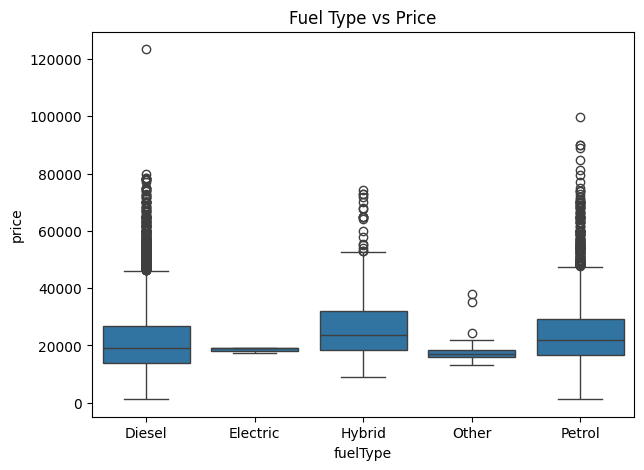

```python
# Fuel Type vs Price
# Examine depreciation of car value with fuel type
# Box plot shows median, quartiles, and outliers for price by fuel type

# Figure size (7 inches wide, 5 inches tall)
plt.figure(figsize=(7, 5))
# Box plot with fuel type on x-axis and price on y-axis
sns.boxplot(x="fuelType", y="price", data=df)
# Title
plt.title("Fuel Type vs Price")
# Display the plot
plt.show()
```

### Fuel Type vs Price

Visualization Type:

- Boxplot

Reason for visualization choice:

- Show variation and median price differences
- Categorical

Findings:

- Price distributions vary by fuel type

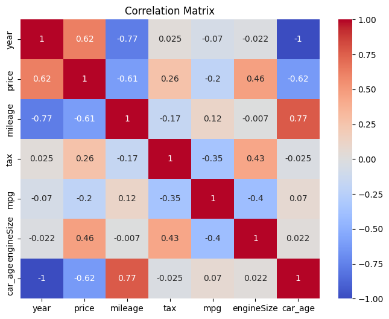

```python
# Correlation matrix - Heatmap
# Identify relationships between numerical features and price

# Figure size (8 inches wide, 6 inches tall)
plt.figure(figsize=(8, 6))
# Calculate correlation matrix for numerical features
sns.heatmap(df.corr(numeric_only=True), annot=True, cmap="coolwarm")
# Title
plt.title("Correlation Matrix")
# Display the plot
plt.show()
```

### Correlation Matrix

Visualization Type:

- Heatmap

Reason for visualization choice:

- Displays relationship between numeric variables
- Allows clear focus on which variables are most strongly associated with price

Findings:

- Year (0.62), mileage (-0.61), and car_age (-0.62) had the strongest relationships with price
- Year & Car Age (-1.0): Perfectly negatively correlated, as expected
- Mileage (-0.61): Higher mileage is strongly associated with lower price

### Visualization Summary

To understand which factors are most strongly associated with price, I examined several visualizations along with a correlation matrix.

The correlation matrix reveals that the strongest relationships with price are year, car_age, and mileage. This suggests that newer vehicles and vehicles with lower mileage tend to have higher prices.

The negative correlation between car_age and price indicates clear depreciation over time. Similarly, higher mileage is strongly associated with lower prices, reinforcing the impact of vehicle usage on value.

Engine size shows a moderate positive correlation with price (0.46), while other variables, such as mpg and tax, show weaker relationships with price.

## Storytelling & Interpretation

The data suggests that vehicle age and mileage are the strongest factors associated with used BMW prices. Both variables show strong negative relationships with price, reflecting expected depreciation patterns in the automotive resale market.

Newer vehicles command higher prices, and vehicles with lower mileage are generally more expensive. These findings align with basic economic intuition, as buyers typically value vehicles that are newer.

Engine size also shows a moderate positive association with price, suggesting that higher performance/ luxury models may command higher prices. However, the relationship is clearly not as strong as age or mileage. This indicates that there are other factors influencing price outside of engine size.

It is also always important to note that correlation does not imply causation. While age and mileage are strongly associated with price, this analysis does not prove they directly cause price changes. Other factors, not included in the dataset, such as vehicle condition, accident history, and geographic location very likely play a significant role.

Overall, the data tells a consistent story of depreciation influenced primarily by age and mileage.

## Limitations, Ethics, & Reflection

Although the dataset provides valuable insight, it has several limitations as well.

First, the dataset only includes BMW vehicles, so findings cannot be generalized to all car brands. Additionally, the dataset does NOT include information about vehicle condition, accident history, geographic location, or seller type (private or dealer). These factors likely influence price but are not captured in this dataset.

The dataset also reflects listing prices rather than final sales prices, which could introduce bias if sellers consistently overprice or underprice vehicles.

There may also be sampling bias, if the dataset reflects listings from a specific market or country.

If additional data were available, I would explore regional price variation and comparison across different car brands.

This project reinforced that data analysis requires careful interpretation and awareness of what the data does and does not capture.

## References & AI Use Transparency

Dataset: BMW Cars Dataset, Kaggle.

AI Use: I used ChatGPT (GPT-5) to assist with improving explanations, understanding syntax, and debugging code.